# Bootstrap Hypothesis Testing

Mark Schulist

2022-11-08

# Setup

Here we have tires and their stopping distances. We want to know if the stop on average less than 130ft since that is what is considered safe.

```r
tires <- c(129, 128, 130, 132, 135, 123, 122, 125, 128, 130)
```

$$\begin{align*}
H_0{:\hspace{0.2cm}} \mu = 130 \\
H_a{:\hspace{0.2cm}} \mu < 130
\end{align*}$$

Parameter of interest: long-run mean stopping distance $(\mu)$.

# Running Samples

Now, we’ll run a bunch of samples with replacement from the data set and collect the mean of the samples.

sample mean = 128.2

sample sd = 3.9944406

sample size = 10

```r
set.seed(7)
boot <- replicate(5000, mean(sample(tires, replace = T)))
sd <- sd(boot)
```

bootstrap sd = 1.1995758

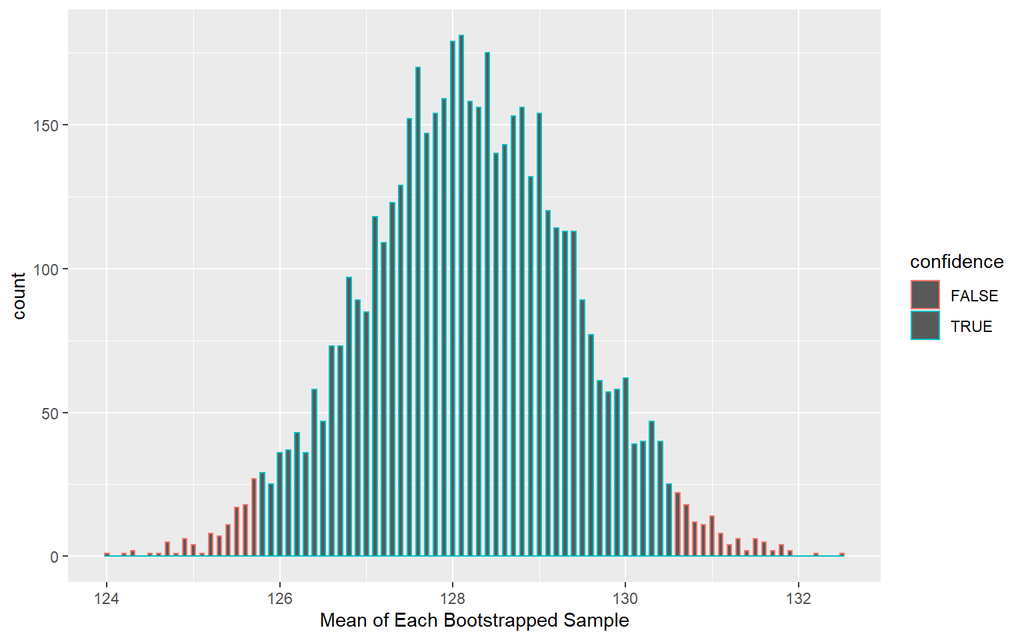

```r
boot_tbl <- boot %>% as_tibble() %>%
  rename(t_vals = 1) %>%
  mutate(
  confidence = (t_vals <= mean(t_vals) + 2 * sd(t_vals)) &
    (t_vals >= mean(t_vals) - 2 * sd(t_vals))
)
ggplot(boot_tbl, aes(t_vals)) +
  geom_histogram(aes(color = confidence), binwidth = 0.05) +
  xlab("Mean of Each Bootstrapped Sample")
```

# Finding 95% Confidence Interval

Now, we’ll find the 95% confidence interval and see if our data is contained within it.

```r
upper = mean(boot) + 2 * sd(boot)
lower = mean(boot) - 2 * sd(boot)
```

Interval: (125.7906, 130.5889)

Since 130 is contained within our 95% confidence interval, we fail to reject our null hypothesis.

# Using Bootstrap to run a Hypothesis Test

We need to shift all of the data points to be at the null distribution mean to conduct a hypothesis test. This can be done by adding the difference between the sample mean and the null distribution mean to each of the bootstrapped data points.

So in this case, the mean of the sample = 128.2 and the mean of the null distribution = 130. So we just need to add 1.8 to all of the data points.

```r
tires_mean <- tires + 1.8
```

Then, we can do a bunch more samples from this new data set.

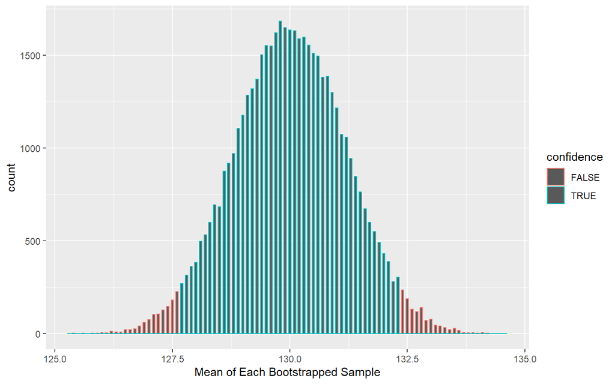

```r
boot_adj <- replicate(50000, mean(sample(tires_mean, replace = T)))

boot_adj_tbl <- boot_adj %>% as_tibble() %>%
  rename(t_vals = 1) %>%
  mutate(
  confidence = (t_vals <= mean(t_vals) + 2 * sd(t_vals)) &
    (t_vals >= mean(t_vals) - 2 * sd(t_vals))
)
ggplot(boot_adj_tbl, aes(t_vals)) +
  geom_histogram(aes(color = confidence), binwidth = 0.05) +
  xlab("Mean of Each Bootstrapped Sample")
```

Now, we can count the number of samples that have means of 128.2 or lower. We then divide this value by the number of samples to get the p-value.

```r
p_value <- sum(boot_adj < 128.2) / length(boot_adj)
```

p-value = 0.0607

This is weak evidence to reject the null hypothesis so we do not reject it.

There is not strong evidence that the tires stop in less than 130 feet.